# Lab04

# Checkpoint 1

Para essa análise será usada uma amostra de dados de atividade de commits de usuários do github.

```r
data <- read_csv("github-users-committing-filetypes.csv")
```

### Escolhendo duas linguagens distintas

Para essa análise serão escolhidas duas liguagens, onde serão comparadas as frequência de commits durante o meio da semana e o final de semana. As linguagens selecionadas serão Python, representada pela extensão *py*, e C++, representada pela extensão *cpp*.

```r
py_cpp_data <- data %>% filter(file_extension %in% c("py", "cpp"))
```

## Para cada uma delas, há uma diferença significativa na sua popularidade durante a semana e durante o fim de semana? Essa diferença é grande?

Vamos agora alterar os dados para sabermos se o dia do commit caiu no meio da semana ou no final da semana.

```r
py_cpp_data <- py_cpp_data %>%
        mutate(type=ifelse(wday(as.Date(paste(the_year, the_month, month_day, sep="-")),
                                label=TRUE) %in% c("Mon", "Tues", "Wed", "Thurs",
                                                   "Fri"),
                           "semana","fim_de_semana"))
```

Vendo graficamente os commits na linguagem Python

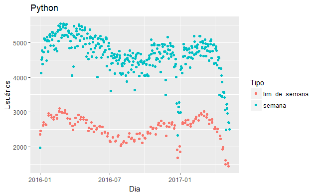

```r
py_cpp_data %>% filter(file_extension=="py") %>%
    ggplot(aes(x=as.Date(paste(the_year, the_month, month_day, sep="-")), y=users)) +
    geom_point(aes(colour=type)) +
    labs(title="Python", x="Dia", y="Usuários", colour="Tipo")
```

Podemos observar que o número de commits durante a semana é bem maior que durante o final de semana nessa amostra, mas é preciso sabe se essa amostra representa a população com um nível de confiança aceitável.

```r
set.seed(1)
py <- py_cpp_data %>% filter(file_extension == "py")
py_week <- py %>% filter(type=="semana")
py_weekend <- py %>% filter(type=="fim_de_semana")
reps = 5000
mean_week_py = bootstrap(py_week,
                        mean(users),
                        R = reps) %>%
    CI.percentile(probs = c(.025, .975))
mean_week_py
```

```
                2.5%    97.5%
mean(users) 4589.786 4710.665
```

```r
mean_weekend_py = bootstrap(py_weekend, mean(users), R = reps) %>%
    CI.percentile(probs = c(.025, .975))
mean_weekend_py
```

```
                2.5%    97.5%
mean(users) 2468.257 2579.694
```

Com 95% de confiança podemos dizer que a média de commits durante a semana está entre 4589.7 e 4710.6, e durante o fim de semana está entre 2468.2 e 2579.6, ou seja, podemos dizer que Python é mais popular durante a semana.  
Vendo graficamente os commits na linguagem C++

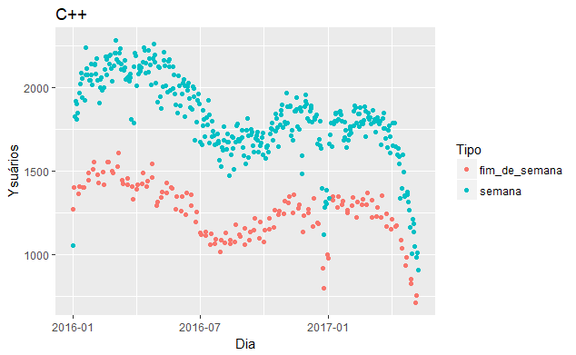

```r
py_cpp_data %>% filter(file_extension=="cpp") %>%
    ggplot(aes(x=as.Date(paste(the_year, the_month, month_day, sep="-")), y=users)) +
    geom_point(aes(colour=type)) +
    labs(title="C++", x="Dia", y="Ysuários", colour="Tipo")
```

```r
set.seed(1)
cpp <- py_cpp_data %>% filter(file_extension == "cpp")
cpp_week <- cpp %>% filter(type=="semana")
cpp_weekend <- cpp %>% filter(type=="fim_de_semana")
reps = 5000
mean_week_cpp = bootstrap(cpp_week,
                        mean(users),
                        R = reps) %>%
    CI.percentile(probs = c(.025, .975))
mean_week_cpp
```

```
               2.5%    97.5%
mean(users) 1795.72 1847.572
```

```r
mean_weekend_cpp = bootstrap(cpp_weekend, mean(users), R = reps) %>%
    CI.percentile(probs = c(.025, .975))
mean_weekend_cpp
```

```
                2.5%    97.5%
mean(users) 1228.372 1285.296
```

## Existe uma diferença significativa entre as duas linguagens na sua variação de popularidade nos finais de semana?

É necessario fazer a diferença entre a semana e o final de semana.

```r
set.seed(1)
bs = bootstrap2(data = py_week$users,
               data2 = py_weekend$users,
               mean)
means_py = CI.percentile(bs, probs = c(.025, .975))
means_py
```

```
                     2.5%    97.5%
mean: data-data2 2042.006 2207.618
```

```r
bs2 = bootstrap2(data = cpp_week$users,
               data2 = cpp_weekend$users,
               mean)
means_cpp = CI.percentile(bs2, probs = c(.025, .975))
means_cpp
```

```
                     2.5%    97.5%
mean: data-data2 526.2544 603.0062
```

```
some row.names duplicated: 2 --> row.names NOT used
```

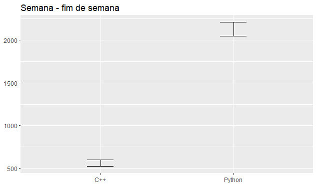

```r
data.frame(rbind(means_py, means_cpp)) %>%
  ggplot(aes(x = c("Python", "C++"), ymin = X2.5., ymax = X97.5.)) +
  geom_errorbar(width = .2) +
  labs(title="Semana - fim de semana", x="")
```

Vendo isso podemos ver que a diferença entre o final de semana e o meio da semna em C++ é bem menor que a de Python, então C++ é mais popular no final de semana.

# Checkpoint 3

Continuando utilizando python e c++ como as linguagens selecionadas para responder as perguntas

## Há uma diferença significativa na sua popularidade no mês de Janeiro e no mês de Dezembro?

Vamos separar os meses de Janeiro e Dezembro e depois calcular o intervalo da média com 95% de confiança

```r
set.seed(1)
py_december <- py %>% filter(the_month==12)
py_january <- py %>% filter(the_month==1)
mean_december_py <- bootstrap(py_december,
                        mean(users),
                        R = reps) %>%
    CI.percentile(probs = c(.025, .975))
mean_december_py
```

```
                2.5%   97.5%
mean(users) 3263.858 4030.91
```

```r
mean_january_py <- bootstrap(py_january,
                        mean(users),
                        R = reps) %>%
    CI.percentile(probs = c(.025, .975))
mean_january_py
```

```
                2.5%    97.5%
mean(users) 3751.715 4286.502
```

Vamos separar os meses de Janeiro e Dezembro e depois calcular o intervalo da média com 95% de confiança

```r
set.seed(1)
cpp_december <- cpp %>% filter(the_month==12)
cpp_january <- cpp %>% filter(the_month==1)
mean_december_cpp <- bootstrap(cpp_december,
                        mean(users),
                        R = reps) %>%
    CI.percentile(probs = c(.025, .975))
mean_december_cpp
```

```
                2.5%    97.5%
mean(users) 1384.644 1620.146
```

```r
mean_january_cpp <- bootstrap(py_january,
                        mean(users),
                        R = reps) %>%
    CI.percentile(probs = c(.025, .975))
mean_january_cpp
```

```
                2.5%    97.5%
mean(users) 3751.715 4286.502
```

## Existe uma diferença na popularidade de Java no começo do mês ou no final do mês?

Vamos definir que começo de mês é do dia 1 ao 10 e fim de mês do dia 20 ao 31. Então separamos esses dias e calculamos o intervalo de suas médias.

```r
set.seed(1)
java <- data %>% filter(file_extension == "java")
java_b_month <- java %>% filter(month_day <= 10)
java_e_month <- java %>% filter(month_day >= 20)
mean_b_java <- bootstrap(java_b_month,
                        mean(users),
                        R = reps) %>%
    CI.percentile(probs = c(.025, .975))
mean_b_java
```

```
                2.5%    97.5%
mean(users) 2945.045 3191.634
```

```r
mean_e_month <- bootstrap(java_e_month,
                        mean(users),
                        R = reps) %>%
    CI.percentile(probs = c(.025, .975))
mean_e_month
```

```
                2.5% 97.5%
mean(users) 3006.553  3250
```

Com 95% de confiança podemos dizer que a média de commits durante o começo do mês está entre 2945.045 e 3191.634, e durante o fim do mês está entre 3006.553 e 3250, ou seja, aparentemente Java não tem diferença se está no começo ou no final do mês, a popularidade da linguagem é a semelhante.

# Checkpoint 4

## Há uma diferença significativa na sua popularidade no mês de Janeiro e no mês de Dezembro?

O p-valor é a probabilidade de encontrar resultados iguais ou maiores que os do experimento quando a hipótese nula é verdadeira.

#### Python

A média de usuários commitando em Janeiro e Dezembro pode ser vista abaixo.

```r
mean2_january_py <- mean(py_january$users)
mean2_january_py
```

```
[1] 4023.081
```

```r
mean2_december_py <- mean(py_december$users)
mean2_december_py
```

```
[1] 3655.323
```

E a diferença entre as médias é de aproximadamente 367.75 usuários.

```r
diff_mean2_py <- mean2_january_py - mean2_december_py
diff_mean2_py
```

```
[1] 367.7581
```

Para estimar o p-valor se vai fazer uma reamostragem das quantidades de usuários embaralhando os meses aos quais as quantidades fazem referência.

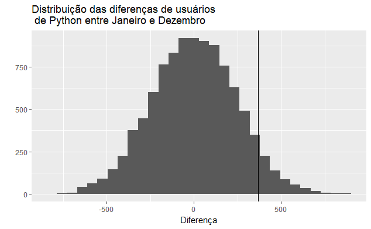

```r
set.seed(1)
diffs_py = replicate(10000, {
  means = py %>%
    mutate(id_shuffled = sample(the_month)) %>%
    group_by(id_shuffled) %>%
    summarise(mean = mean(users))
  py2_january <- means %>% filter(id_shuffled==1)
  py2_december <- means %>% filter(id_shuffled==12)
  return(py2_january$mean - py2_december$mean)
})
tibble(diff = diffs_py) %>%
  ggplot(aes(x = diff)) +
  geom_histogram(bins = 30) +
  geom_vline(xintercept = diff_mean2_py) +
  labs(title="Distribuição das diferenças de usuários\n de Python entre Janeiro e Dezembro",
       x="Diferença", y="")
```

```r
sum(abs(diffs_py) >= abs(diff_mean2_py)) / length(diffs_py)
```

```
[1] 0.1271
```

O p-valor encontrado é 0.1271, indicando que aproximadamente *12.7%* da reamostragem o valor da diferença é maior ou igual ao encontrado na amostra. Como se utiliza *0.05%* como comparação, o valor encontrado é maior então não há indicios de que a hipótese nula não é verdadeira.

#### C++

A média de usuários commitando em Janeiro e Dezembro pode ser vista abaixo.

```r
mean2_january_cpp <- mean(cpp_january$users)
mean2_january_cpp
```

```
[1] 1697.339
```

```r
mean2_december_cpp <- mean(cpp_december$users)
mean2_december_cpp
```

```
[1] 1503.774
```

E a diferença entre as médias é de aproximadamente 193.56 usuários.

```r
diff_mean2_cpp <- mean2_january_cpp - mean2_december_cpp
diff_mean2_cpp
```

```
[1] 193.5645
```

Para estimar o p-valor se vai fazer uma reamostragem das quantidades de usuários embaralhando os meses aos quais as quantidades fazem referência.

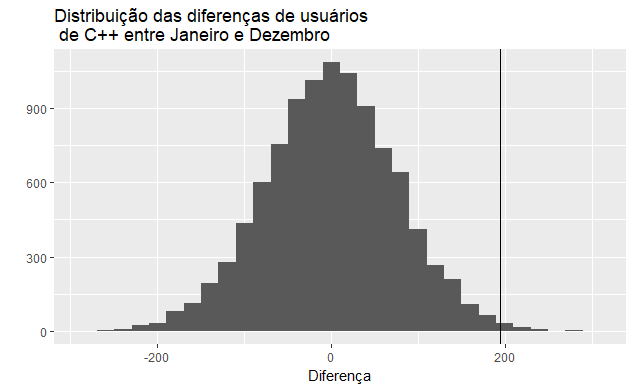

```r
set.seed(1)
diffs_cpp = replicate(10000, {
  means = cpp %>%
    mutate(id_shuffled = sample(the_month)) %>%
    group_by(id_shuffled) %>%
    summarise(mean = mean(users))
  cpp2_january <- means %>% filter(id_shuffled==1)
  cpp2_december <- means %>% filter(id_shuffled==12)
  return(cpp2_january$mean - cpp2_december$mean)
})
tibble(diff = diffs_cpp) %>%
  ggplot(aes(x = diff)) +
  geom_histogram(bins = 30) +
  geom_vline(xintercept = diff_mean2_cpp) +
  labs(title="Distribuição das diferenças de usuários\n de C++ entre Janeiro e Dezembro",
       x="Diferença", y="")
```

Podemos observar que a linha está bem a frente do centro da distribuição indicando que provavelmente a hipótese nula não é verdadeira e que a diferença de usuário de Janeiro e Dezembro é significativa.

```r
sum(abs(diffs_cpp) >= abs(diff_mean2_cpp)) / length(diffs_cpp)
```

```
[1] 0.0108
```